# P1--Web Traffic -Time Series

```python
import warnings
warnings.filterwarnings('ignore')
```

```python
from statsmodels.graphics.tsaplots import plot_acf,plot_pacf
```

```python
from statsmodels.tsa.statespace import sarimax
from statsmodels.tsa.stattools import adfuller,ARMA
from statsmodels.tsa.statespace.tools import diff
from statsmodels.tsa.arima_model import ARIMA,ARMA,ARMAResults,ARIMAResults
```

```python
from statsmodels.tsa.statespace.sarimax import SARIMAX
```

```python
df=pd.read_csv(r'C:\Users\surya pavan\Downloads\Web Traffic ds\daily-website-visitors.csv',index_col='Date',parse_dates=True)
```

```python
from pmdarima import auto_arima
```

```python
df.isnull().sum()
```

```
Row                  0
Day                  0
Day.Of.Week          0
Page.Loads           0
Unique.Visits        0
First.Time.Visits    0
Returning.Visits     0
dtype: int64
```

```python
df.shape
```

```
(2167, 7)
```

```python
df.head()
```

| Date | Row | Day | Day.Of.Week | Page.Loads | Unique.Visits | First.Time.Visits | Returning.Visits |
| --- | --- | --- | --- | --- | --- | --- | --- |
| 2014-09-14 | 1 | Sunday | 1 | 2,146 | 1,582 | 1,430 | 152 |
| 2014-09-15 | 2 | Monday | 2 | 3,621 | 2,528 | 2,297 | 231 |
| 2014-09-16 | 3 | Tuesday | 3 | 3,698 | 2,630 | 2,352 | 278 |
| 2014-09-17 | 4 | Wednesday | 4 | 3,667 | 2,614 | 2,327 | 287 |
| 2014-09-18 | 5 | Thursday | 5 | 3,316 | 2,366 | 2,130 | 236 |

```python
df.rename(columns = {'Day.Of.Week':'day_of_week'
                    ,'Page.Loads':'page_loads'
                    ,'Unique.Visits':'unique_visits'
                    ,'First.Time.Visits':'first_visits'
                    ,'Returning.Visits':'returning_visits'}, inplace = True)
```

```python
df.index.nunique()
```

```
2167
```

```python
df.Row.nunique()
```

```
2167
```

```python
df.info()
```

```
<class 'pandas.core.frame.DataFrame'>
DatetimeIndex: 2167 entries, 2014-09-14 to 2020-08-19
Data columns (total 7 columns):
 #   Column            Non-Null Count  Dtype
---  ------            --------------  -----
 0   Row               2167 non-null   int64
 1   Day               2167 non-null   object
 2   day_of_week       2167 non-null   int64
 3   page_loads        2167 non-null   object
 4   unique_visits     2167 non-null   object
 5   first_visits      2167 non-null   object
 6   returning_visits  2167 non-null   object
dtypes: int64(2), object(5)
memory usage: 135.4+ KB
```

```python
df.columns
```

```
Index(['Row', 'Day', 'day_of_week', 'page_loads', 'unique_visits',
       'first_visits', 'returning_visits'],
      dtype='object')
```

```python
ls=(['Row', 'Day', 'day_of_week', 'page_loads', 'unique_visits',
       'first_visits', 'returning_visits'])
```

```python
df.replace(',','',inplace=True,regex=True)
```

```python
df.head()
```

| Date | Row | Day | day_of_week | page_loads | unique_visits | first_visits | returning_visits |
| --- | --- | --- | --- | --- | --- | --- | --- |
| 2014-09-14 | 1 | Sunday | 1 | 2146 | 1582 | 1430 | 152 |
| 2014-09-15 | 2 | Monday | 2 | 3621 | 2528 | 2297 | 231 |
| 2014-09-16 | 3 | Tuesday | 3 | 3698 | 2630 | 2352 | 278 |
| 2014-09-17 | 4 | Wednesday | 4 | 3667 | 2614 | 2327 | 287 |
| 2014-09-18 | 5 | Thursday | 5 | 3316 | 2366 | 2130 | 236 |

```python
liss=['page_loads', 'unique_visits','first_visits', 'returning_visits']
```

```python
for i in liss:
    df[i]=df [i].astype(int)
```

```python
df.info()
```

```
<class 'pandas.core.frame.DataFrame'>
DatetimeIndex: 2167 entries, 2014-09-14 to 2020-08-19
Data columns (total 7 columns):
 #   Column            Non-Null Count  Dtype
---  ------            --------------  -----
 0   Row               2167 non-null   int64
 1   Day               2167 non-null   object
 2   day_of_week       2167 non-null   int64
 3   page_loads        2167 non-null   int32
 4   unique_visits     2167 non-null   int32
 5   first_visits      2167 non-null   int32
 6   returning_visits  2167 non-null   int32
dtypes: int32(4), int64(2), object(1)
memory usage: 101.6+ KB
```

```python
df.tail()
```

| Date | Row | Day | day_of_week | page_loads | unique_visits | first_visits | returning_visits |
| --- | --- | --- | --- | --- | --- | --- | --- |
| 2020-08-15 | 2163 | Saturday | 7 | 2221 | 1696 | 1373 | 323 |
| 2020-08-16 | 2164 | Sunday | 1 | 2724 | 2037 | 1686 | 351 |
| 2020-08-17 | 2165 | Monday | 2 | 3456 | 2638 | 2181 | 457 |
| 2020-08-18 | 2166 | Tuesday | 3 | 3581 | 2683 | 2184 | 499 |
| 2020-08-19 | 2167 | Wednesday | 4 | 2064 | 1564 | 1297 | 267 |

```python
df.index
```

```
DatetimeIndex(['2014-09-14', '2014-09-15', '2014-09-16', '2014-09-17',
               '2014-09-18', '2014-09-19', '2014-09-20', '2014-09-21',
               '2014-09-22', '2014-09-23',
               ...
               '2020-08-10', '2020-08-11', '2020-08-12', '2020-08-13',
               '2020-08-14', '2020-08-15', '2020-08-16', '2020-08-17',
               '2020-08-18', '2020-08-19'],
              dtype='datetime64[ns]', name='Date', length=2167, freq=None)
```

```python
df.index.freq="D"
```

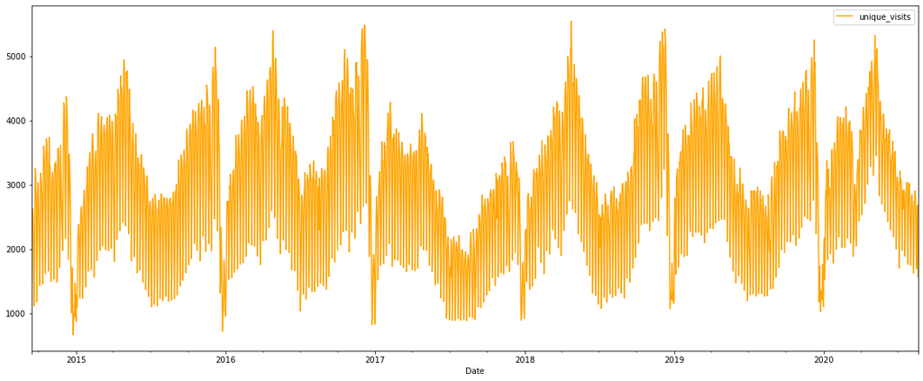

```python
df['unique_visits'].plot(figsize=(20,8),legend=True,c='Orange')
```

The above data plot of unique visitors looks stationary.We can verify this using adfuller method

```python
dsp=df.groupby(['Day'])['unique_visits'].agg(['sum']).sort_values(by='sum',ascending=False)
```

```python
dsp['sum'].sum()
```

```
6378882
```

```python
df['unique_visits'].sum()
```

```
6378882
```

We can see that in both the dataframes the unique visits are same. One dataframe implies days of a week and another one implies total dataframe.

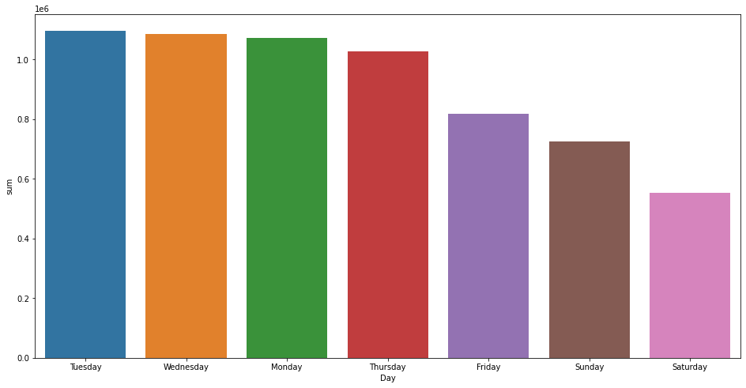

```python
import matplotlib
matplotlib.rcParams["figure.figsize"]=(16,8)
sns.barplot(x=dsp.index,y=dsp['sum'],data=dsp)
```

As we can observe from the above bar plot, that "Tuesday, Wednesday, Monday, Thursday" has the most unique visits to the notebook site.

Weekends has low traffic to the site.May be the reason of holidays.Students are enjoying weekends.

```python
df.columns
```

```
Index(['Row', 'Day', 'day_of_week', 'page_loads', 'unique_visits',
       'first_visits', 'returning_visits'],
      dtype='object')
```

```python
sums=df.groupby(['Day'])[['page_loads','unique_visits','first_visits','returning_visits']].sum().sort_values(by='unique_visits',ascending=False)
```

```python
sums
```

| Day | page_loads | unique_visits | first_visits | returning_visits |
| --- | --- | --- | --- | --- |
| Tuesday | 1536154 | 1097181 | 907752 | 189429 |
| Wednesday | 1517114 | 1085624 | 897602 | 188022 |
| Monday | 1502161 | 1072112 | 886036 | 186076 |
| Thursday | 1437269 | 1028214 | 848921 | 179293 |
| Friday | 1149437 | 817852 | 668805 | 149047 |
| Sunday | 1006564 | 725794 | 604198 | 121596 |
| Saturday | 772817 | 552105 | 456449 | 95656 |

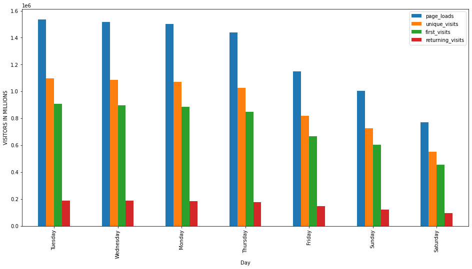

```python
sums.plot(kind='bar',ylabel='VISITORS IN MILLIONS')
```

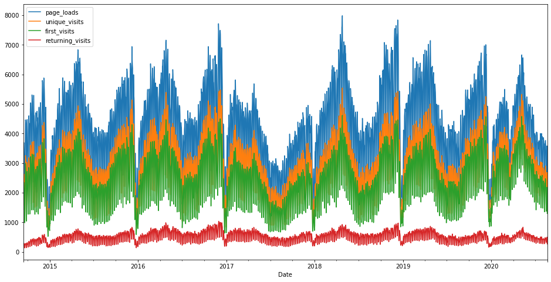

```python
df[['page_loads','unique_visits','first_visits','returning_visits']].plot()
```

```python
df.head()
```

| Date | Row | Day | day_of_week | page_loads | unique_visits | first_visits | returning_visits |
| --- | --- | --- | --- | --- | --- | --- | --- |
| 2014-09-14 | 1 | Sunday | 1 | 2146 | 1582 | 1430 | 152 |
| 2014-09-15 | 2 | Monday | 2 | 3621 | 2528 | 2297 | 231 |
| 2014-09-16 | 3 | Tuesday | 3 | 3698 | 2630 | 2352 | 278 |
| 2014-09-17 | 4 | Wednesday | 4 | 3667 | 2614 | 2327 | 287 |
| 2014-09-18 | 5 | Thursday | 5 | 3316 | 2366 | 2130 | 236 |

```python
Month_res=df[['page_loads','unique_visits','first_visits','returning_visits']].resample('M').mean()
```

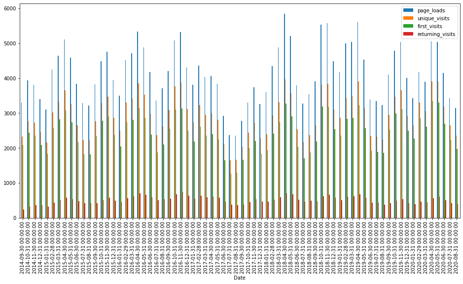

```python
Month_res.plot(kind='bar')
```

May be the reason of holidays to that center.

```python
 yearly_res=df[['page_loads','unique_visits','first_visits','returning_visits']].resample('A').mean()
```

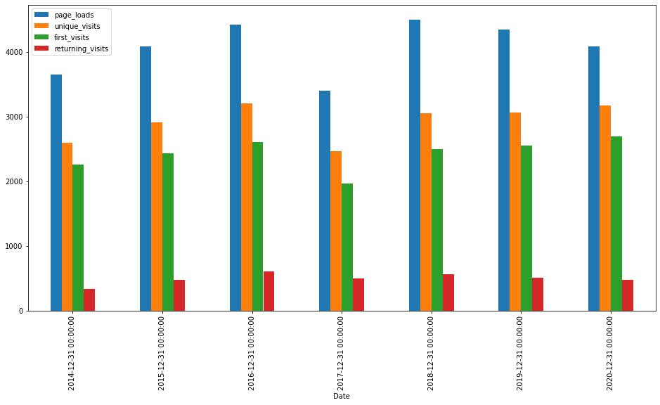

```python
yearly_res.plot(kind='bar')
```

From the above plot, we observe that 2017 year as very less page loads than all the years.

```python
df.head()
```

| Date | Row | Day | day_of_week | page_loads | unique_visits | first_visits | returning_visits |
| --- | --- | --- | --- | --- | --- | --- | --- |
| 2014-09-14 | 1 | Sunday | 1 | 2146 | 1582 | 1430 | 152 |
| 2014-09-15 | 2 | Monday | 2 | 3621 | 2528 | 2297 | 231 |
| 2014-09-16 | 3 | Tuesday | 3 | 3698 | 2630 | 2352 | 278 |
| 2014-09-17 | 4 | Wednesday | 4 | 3667 | 2614 | 2327 | 287 |
| 2014-09-18 | 5 | Thursday | 5 | 3316 | 2366 | 2130 | 236 |

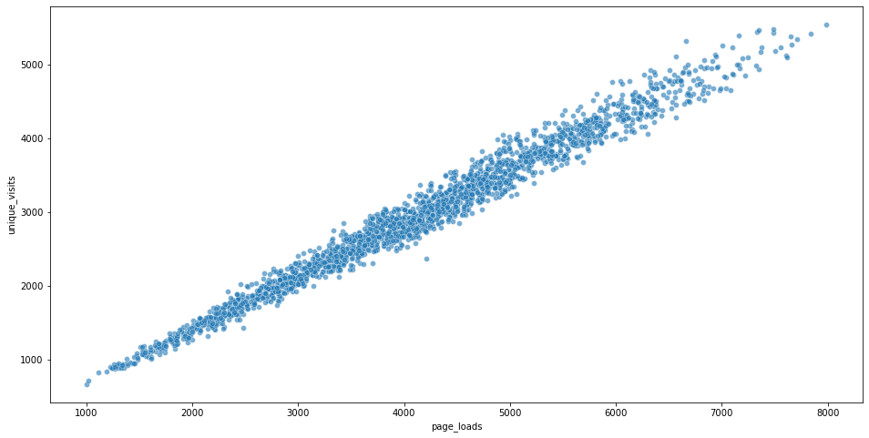

```python
sns.scatterplot(x='page_loads',y='unique_visits',data=df,alpha=0.6)
```

### Testing for Stationarity in unique_visits

```python
adf=adfuller(df['unique_visits'],autolag='AIC')
```

```python
adf[4]
```

```
{'1%': -3.4334094211542983,
 '5%': -2.8628915360971003,
 '10%': -2.5674894918770197}
```

```python
labels=['adf','pvalue','usedlag','nobs']
```

```python
ass_var=pd.Series(data=adf[:4],index=labels)
```

```python
ass_var
```

```
adf          -4.475969
pvalue        0.000217
usedlag      26.000000
nobs       2140.000000
dtype: float64
```

```python
for key,value in adf[4].items():
    ass_var[f'Critical value ({key})']=value
```

```python
ass_var
```

```
adf                       -4.475969
pvalue                     0.000217
usedlag                   26.000000
nobs                    2140.000000
Critical value (1%)       -3.433409
Critical value (5%)       -2.862892
Critical value (10%)      -2.567489
dtype: float64
```

P value is 0.000217 which is less than 0.05. This mean, that we reject null hypothesis and accept alternate hypothesis.

Which indicates that our data is stationary .

#### Finding orders of ARIMA, SARIMA using grid search technique of Auto_arima

```python
auto_arima(df['unique_visits'],seasonal=True,trace=True,stationary=True,start_p=0,start_q=0,m=7,step_wise=True).summary()
```

```
Performing stepwise search to minimize aic
 ARIMA(0,0,0)(1,0,1)[7] intercept   : AIC=32982.924, Time=1.78 sec
 ARIMA(0,0,0)(0,0,0)[7] intercept   : AIC=35993.975, Time=0.04 sec
 ARIMA(1,0,0)(1,0,0)[7] intercept   : AIC=30200.417, Time=2.00 sec
 ARIMA(0,0,1)(0,0,1)[7] intercept   : AIC=32633.516, Time=1.04 sec
 ARIMA(0,0,0)(0,0,0)[7]             : AIC=40995.839, Time=0.02 sec
 ARIMA(1,0,0)(0,0,0)[7] intercept   : AIC=34140.120, Time=0.11 sec
 ARIMA(1,0,0)(2,0,0)[7] intercept   : AIC=31523.872, Time=4.47 sec
 ARIMA(1,0,0)(1,0,1)[7] intercept   : AIC=30333.907, Time=2.31 sec
 ARIMA(1,0,0)(0,0,1)[7] intercept   : AIC=32420.367, Time=0.79 sec
 ARIMA(1,0,0)(2,0,1)[7] intercept   : AIC=inf, Time=3.26 sec
 ARIMA(0,0,0)(1,0,0)[7] intercept   : AIC=32452.801, Time=1.25 sec
 ARIMA(2,0,0)(1,0,0)[7] intercept   : AIC=32050.361, Time=2.91 sec
 ARIMA(1,0,1)(1,0,0)[7] intercept   : AIC=31040.394, Time=2.03 sec
 ARIMA(0,0,1)(1,0,0)[7] intercept   : AIC=31085.433, Time=1.80 sec
 ARIMA(2,0,1)(1,0,0)[7] intercept   : AIC=inf, Time=2.93 sec
 ARIMA(1,0,0)(1,0,0)[7]             : AIC=inf, Time=0.86 sec

Best model:  ARIMA(1,0,0)(1,0,0)[7] intercept
Total fit time: 27.584 seconds
```

SARIMAX Results

| Dep. Variable: | y | No. Observations: | 2167 |
| --- | --- | --- | --- |
| Model: | SARIMAX(1, 0, 0)x(1, 0, 0, 7) | Log Likelihood | -15096.209 |
| Date: | Thu, 21 Jul 2022 | AIC | 30200.417 |
| Time: | 13:23:22 | BIC | 30223.141 |
| Sample: | 0 | HQIC | 30208.727 |
|  | - 2167 |  |  |
| Covariance Type: | opg |  |  |

|  | coef | std err | z | P>\|z\| | [0.025 | 0.975] |
| --- | --- | --- | --- | --- | --- | --- |
| intercept | 60.0262 | 8.491 | 7.069 | 0.000 | 43.384 | 76.668 |
| ar.L1 | 0.8063 | 0.008 | 99.740 | 0.000 | 0.791 | 0.822 |
| ar.S.L7 | 0.8874 | 0.009 | 98.946 | 0.000 | 0.870 | 0.905 |
| sigma2 | 6.497e+04 | 1516.581 | 42.837 | 0.000 | 6.2e+04 | 6.79e+04 |

| Ljung-Box (L1) (Q): | 5.65 | Jarque-Bera (JB): | 232.06 |
| --- | --- | --- | --- |
| Prob(Q): | 0.02 | Prob(JB): | 0.00 |
| Heteroskedasticity (H): | 1.26 | Skew: | -0.00 |
| Prob(H) (two-sided): | 0.00 | Kurtosis: | 4.60 |

Warnings:  
[1] Covariance matrix calculated using the outer product of gradients (complex-step).

From the results, the order of arima is (1,0,0) and seasonal order is (1,0,0). This order is based on the least AIC.

##### Splitting data into train and test

```python
df.shape
```

```
(2167, 7)
```

```python
train=df[:2107]
```

```python
test=df[2107:]
```

```python
model=ARIMA(df['unique_visits'],order=(1,0,0))
```

```python
mfit=model.fit()
```

```python
start=len(train)
end=len(train)+len(test)-1
```

```python
predictions=mfit.predict(start=start,end=end,typ='levels')
```

```python
from statsmodels.tools.eval_measures import rmse,meanabs,mse
```

```python
predictions.mean()
```

```
2699.297652170231
```

```python
test['unique_visits'].mean()
```

```
2612.516666666667
```

```python
rmse(test['unique_visits'],predictions)
```

```
443.7708655267197
```

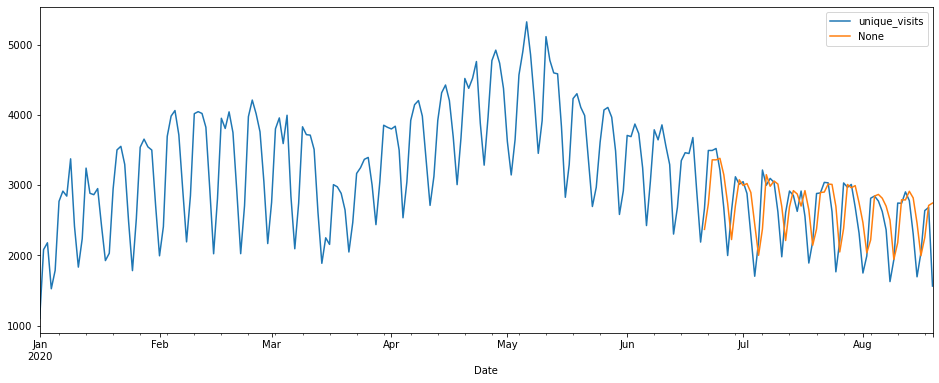

```python
df['unique_visits'].loc['2020-01-01':'2020-08-19'].plot(figsize=(16,6),legend=True)
predictions.plot(legend=True)
```

We got 443 value of RMSE score.We have used ARIMA model for the test data forecasting. The data has seasonality, if we can use SARIMA model, then the test predictions will be predicted better and RMSE value will be decreased

##### SARIMA MODEL

```python
model1=SARIMAX(df['unique_visits'],order=(1,0,0),seasonal_order=(1,0,0,7),enforce_invertibility=False)
```

```python
mod1_fit=model1.fit()
```

```python
predictions1=mod1_fit.predict(start=start,end=end,typ='levels')
```

```python
rmse(test['unique_visits'],predictions1)
```

```
253.25701698994212
```

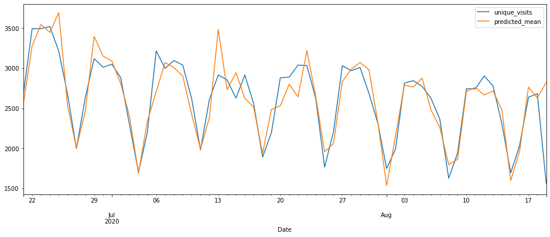

```python
test['unique_visits'].plot(figsize=(16,6),legend=True)
predictions1.plot(legend=True)
```

```python
predictions1.mean()
```

```
2621.7074492557745
```

```python
test['unique_visits'].mean()
```

```
2612.516666666667
```

We can clearly observe that using SARIMA model, the RMSE score has been decreased half of the RMSE score of ARIMA model.

We can also observe the graph, which was aligned better with test data than with the ARIMA test data.

#### SARIMAX Model

Now, we are implementing SARIMAX model by giving exogeneous variable to the model

Here, we are giving "page_loads" as exogenous variable

```python
model1=SARIMAX(df['unique_visits'],order=(1,0,0),seasonal_order=(1,0,0,7),exog=df[['page_loads']],enforce_invertibility=False)
```

```python
mod2_fit=model1.fit()
```

```python
predictions2=mod2_fit.predict(start=start,end=end,typ='levels')
```

```python
test['unique_visits'].mean()
```

```
2612.516666666667
```

```python
predictions2.mean()
```

```
2568.064068141255
```

```python
rmse(test['unique_visits'],predictions2)
```

```
74.87219403852013
```

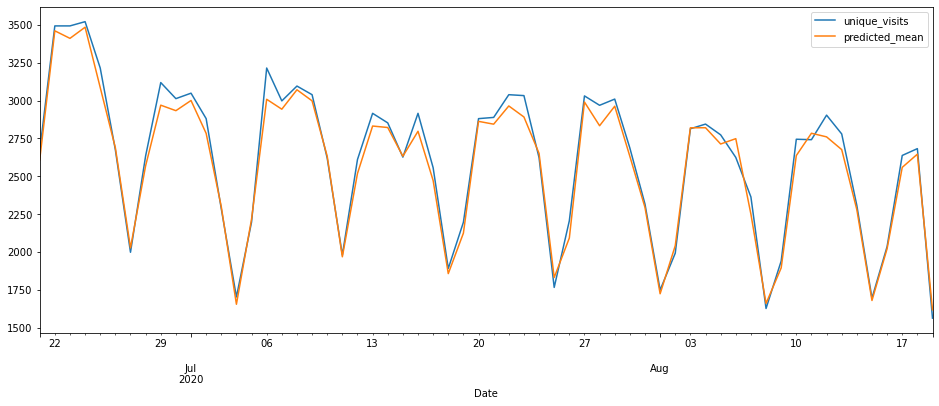

```python
test['unique_visits'].plot(figsize=(16,6),legend=True)
predictions2.plot(legend=True)
```

We can cogently observer that, the predictions are aligned with the test data better than all the other models.

Here we have given page_loads as egog, but now, we are taking the entire dataset into train and test for next 2 months as test data. But, the thing is we don't know future exog data(i.e., page_load data for the future).

So, we are conidering SARIMA model for future predictions of Unique_visits.

```python
fin_mod=SARIMAX(df['unique_visits'],order=(1,0,0),seasonal_order=(1,0,0,7),enforce_invertibility=False)
```

```python
fin_mod_fit=fin_mod.fit()
```

```python
fin_pred=fin_mod_fit.predict(start=len(df['unique_visits']),end=len(df['unique_visits'])+60,typ='levels')
```

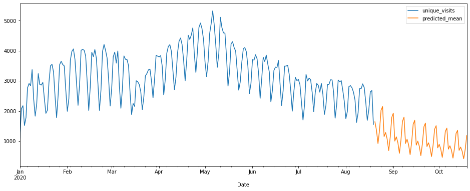

```python
df['unique_visits'].loc['2020-01-01':'2020-08-19'].plot(figsize=(16,6),legend=True)
fin_pred.plot(legend=True)
```

### Conclusion

We conclude that, Using SARIMAX model without exogenous, predicting for the next 2 months results in the downward trend as shown in the above plot with yellow marking.

The best results, we can observe from the all the deployed models is SARIMAX exogenous model. We have got very less RMSE score.